# Cluster Analysis:

we'll show how the K-means algorithm works with a sample dataset of delivery fleet driver data. For the sake of simplicity, we'll only be looking at two driver features: mean distance driven per day and the mean percentage of time a driver was >5 mph over the speed limit. In general, this algorithm can be used for any number of features, so long as the number of data samples is much greater than the number of features.

```python
import pandas as pd
import numpy as np
import matplotlib.pyplot as plt
import seaborn as sns
import statsmodels.api as sm
```

Loading the data into python environment from local system driver_data.csv file

```python
driver_data = pd.read_csv('driver_data.csv')
print('Shape of the Dataset-->',driver_data.shape)
```

```
Shape of the Dataset--> (4000, 2)
```

The chart below shows the dataset for 4,000 drivers, with the distance feature and speeding feature .

Print the top 5 rows of data file loaded

```python
driver_data.head()
```

|  | Distance_Feature | Speeding_Feature |
| --- | --- | --- |
| 0 | 71.24 | 28 |
| 1 | 52.53 | 25 |
| 2 | 64.54 | 27 |
| 3 | 55.69 | 22 |
| 4 | 54.58 | 25 |

Column names of the dataset

```python
driver_data.columns
```

```
Index(['Distance_Feature', 'Speeding_Feature'], dtype='object')
```

Checking weather there are any null values in that 2 feature and there count

```python
driver_data.isnull().sum()
```

```
Distance_Feature    0
Speeding_Feature    0
dtype: int64
```

Entire information of the data columns,type,memory usage.

```python
driver_data.info()
```

```
<class 'pandas.core.frame.DataFrame'>
RangeIndex: 4000 entries, 0 to 3999
Data columns (total 2 columns):
Distance_Feature    4000 non-null float64
Speeding_Feature    4000 non-null int64
dtypes: float64(1), int64(1)
memory usage: 62.6 KB
```

Using visualization check the null values in the dataset

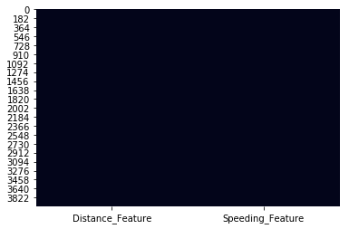

```python
sns.heatmap(driver_data.isnull(), cbar=False)
```

Describing the entire datas mean,std,min,max of all the features in that data

```python
driver_data.describe()
```

|  | Distance_Feature | Speeding_Feature |
| --- | --- | --- |
| count | 4000.000000 | 4000.000000 |
| mean | 76.041523 | 10.721000 |
| std | 53.469563 | 13.708543 |
| min | 15.520000 | 0.000000 |
| 25% | 45.247500 | 4.000000 |
| 50% | 53.330000 | 6.000000 |
| 75% | 65.632500 | 9.000000 |
| max | 244.790000 | 100.000000 |

plotting the data using seaborn

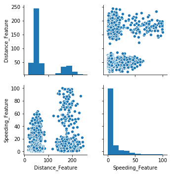

```python
sns.pairplot(driver_data)
plt.show()
```

Finding the co relation between the 2 features Distance_feature and Speeding_Feature

```python
driver_data["Distance_Feature"].corr(driver_data["Speeding_Feature"])
```

```
0.2668967587681438
```

The co-relation between Distance_feature and Speeding_Feature is 0.26 here we can see that the co-relation is very week.

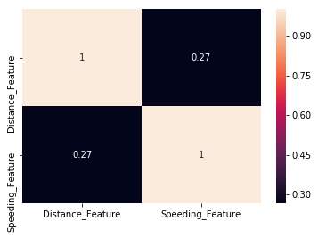

```python
correlation_matrix = driver_data.corr()
sns.heatmap(data=correlation_matrix, annot=True)
```

All of the Machine Learning algorithm that are based on some distance based metric, such as Euclidean distance, are adversely affected if the input values are not standardized to a range.

Feature standardization makes the values of each feature in the data have zero-mean (when subtracting the mean in the numerator) and unit-variance. This method is widely used for normalization in many machine learning algorithms. The general method of calculation is to determine the distribution mean and standard deviation for each feature. Next we subtract the mean from each feature. Then we divide the values (mean is already subtracted) of each feature by its standard deviation.

Import StandardScaler and fit to the dataset (driver_data) and Transform the fit model.

```python
from sklearn.preprocessing import StandardScaler
std_scale = StandardScaler().fit(driver_data)
```

```python
driver_data_scaled = std_scale.transform(driver_data)
driver_data_scaled[:5,]
```

```
array([[-0.0898104 ,  1.26061251],
       [-0.43977285,  1.04174351],
       [-0.215131  ,  1.18765617],
       [-0.38066642,  0.8228745 ],
       [-0.40142849,  1.04174351]])
```

plot the data points into a scatter plot with the distance feature on the x-axis and speeding feature on the y-axis.

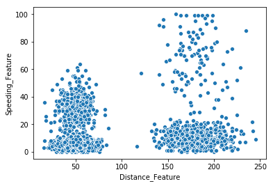

```python
sns.scatterplot(x="Distance_Feature", y="Speeding_Feature", data=driver_data)
```

# Kmeans cluster :

We are given a data set of items, with certain features, and values for these features (like a vector). The task is to categorize those items into groups. To achieve this, we will use the kMeans algorithm; an unsupervised learning algorithm.

By looking at the Scatter plot ploted looks like it fit for 2 cluster let we initially check with 2 clusters using kmeans with random state of 999 with out Standardization

```python
from sklearn.cluster import KMeans
km_data=KMeans(n_clusters=2, random_state=999)
```

Fit the data to the model of kmeans

```python
km_data.fit(driver_data)
```

```
KMeans(algorithm='auto', copy_x=True, init='k-means++', max_iter=300,
    n_clusters=2, n_init=10, n_jobs=None, precompute_distances='auto',
    random_state=999, tol=0.0001, verbose=0)
```

Final Cluster centroids of the model after default n_init and max_iteration as 10 and 300 with 2 clusters

```python
km_data.cluster_centers_
```

```
array([[ 50.04763437,   8.82875   ],
       [180.017075  ,  18.29      ]])
```

By looking at the Scatter plot ploted looks like it fit for 2 cluster let we initially check with 2 clusters using kmeans with random state of 999 with Standardization

```python
km_scaled = KMeans(n_clusters=2, random_state=999)
```

```python
km_scaled.fit(driver_data_scaled)
```

```
KMeans(algorithm='auto', copy_x=True, init='k-means++', max_iter=300,
    n_clusters=2, n_init=10, n_jobs=None, precompute_distances='auto',
    random_state=999, tol=0.0001, verbose=0)
```

Make predictions for the clusters of the given dataset.

```python
predicted_cluster_2 = km_scaled.predict(driver_data_scaled)
```

Printing the 1st 5 outputs of the predicted values of which cluster

```python
predicted_cluster_2[:5]
```

```
array([0, 0, 0, 0, 0])
```

Final Cluster centroids of the model after default n_init and max_iteration as 10 and 300 with 2 clusters

```python
km_scaled.cluster_centers_
```

```
array([[-0.48581565, -0.13816168],
       [ 1.94630276,  0.55351131]])
```

```python
km_scaled.labels_
```

```
array([0, 0, 0, ..., 1, 1, 1])
```

Plot a visualization plot of data clustered into 2 clusters with their centroids and different colors for 2 clusters with legands and the distance feature on the x-axis and speeding feature on the y-axis.

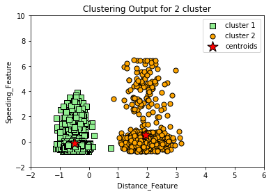

```python
plt.scatter(driver_data_scaled[predicted_cluster_2==0,0], driver_data_scaled[predicted_cluster_2==0, 1], s=50, c='lightgreen',\
           marker='s', edgecolors='black', label='cluster 1')
plt.scatter(driver_data_scaled[predicted_cluster_2==1,0], driver_data_scaled[predicted_cluster_2==1, 1], s=50, c='orange',\
           marker='o', edgecolors='black', label='cluster 2')

plt.scatter(km_scaled.cluster_centers_[:,0], km_scaled.cluster_centers_[:,1], s=250, c='red',\
           marker='*', edgecolors='black', label='centroids')
plt.legend(scatterpoints=1)
plt.xlabel("Distance_Feature")
plt.ylabel("Speeding_Feature")
plt.title("Clustering Output for 2 cluster")
plt.ylim(-2, 10)
plt.xlim(-2,6)
plt.show()
```

# Interpretation

```
Group 1 Centroid = [-0.48581565, -0.13816168]
Group 2 Centroid = [ 1.94630276,  0.55351131]
```

Using the dataset, we can infer that Group 1 is town drivers and Group 2 is city drivers.

Using the help of elbow technique we can find the no of clusters suitable for our data features using SSQ(Sum of squared errors) 1 too 11 cluster points.

```python
# from sklearn.cluster import KMeans
ssq = []
for K in range(1,11):
    kmeans_model = KMeans(n_clusters=K, random_state=999)
    kmeans_model.fit(driver_data_scaled)
    ssq.append(kmeans_model.inertia_)
```

```python
ssq
```

```
[8000.0,
 3911.926390428416,
 1756.544582131428,
 739.1534508645581,
 619.4037594867996,
 502.03685490351063,
 438.7263863946827,
 374.81243086463644,
 337.14757664399974,
 305.65252565141304]
```

Plot the SSq values in a line graph pointing all the 10 cluster points

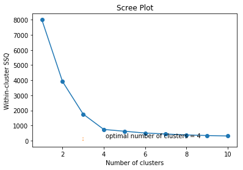

```python
import matplotlib.pyplot as plt
%matplotlib inline

plt.plot(range(1,11), ssq, marker='o')
plt.xlabel("Number of clusters")
plt.ylabel("Within-cluster SSQ")
plt.title("Scree Plot")
plt.plot([3]*200, range(1,201), ":")
plt.text(4.1, 201, "optimal number of clusters = 4")
plt.show()
```

Test how the results look for K=4. To do this, all you need to change is the target number of clusters in the KMeans() function.

Fit the number of cluster 4 with random state 999 using kmeans without standardization

```python
km_data_1=KMeans(n_clusters=4, random_state=999)
```

```python
km_data_1.fit(driver_data)
```

```
KMeans(algorithm='auto', copy_x=True, init='k-means++', max_iter=300,
    n_clusters=4, n_init=10, n_jobs=None, precompute_distances='auto',
    random_state=999, tol=0.0001, verbose=0)
```

Final Cluster centroids of the model after default n_init and max_iteration as 10 and 300 with 4 clusters

```python
km_data_1.cluster_centers_
```

```
array([[180.34311782,  10.52011494],
       [ 49.99263253,   5.20447169],
       [ 50.40482436,  32.36533958],
       [177.83509615,  70.28846154]])
```

```python
km_scaled_1 = KMeans(n_clusters=4, random_state=999)
```

```python
km_scaled_1.fit(driver_data_scaled)
```

```
KMeans(algorithm='auto', copy_x=True, init='k-means++', max_iter=300,
    n_clusters=4, n_init=10, n_jobs=None, precompute_distances='auto',
    random_state=999, tol=0.0001, verbose=0)
```

```python
from sklearn.metrics.pairwise import euclidean_distances
dists = euclidean_distances(km_scaled_1.cluster_centers_)
print(dists)
```

```
[[0.         2.47016299 1.98160235 5.31624157]
 [2.47016299 0.         2.90744404 4.36006625]
 [1.98160235 2.90744404 0.         3.65185048]
 [5.31624157 4.36006625 3.65185048 0.        ]]
```

Predicting the model with the driver_data_scaled

```python
predicted_cluster_4 = km_scaled_1.predict(driver_data_scaled)
```

```python
predicted_cluster_4[:100]
```

```
array([2, 2, 2, 2, 2, 0, 2, 0, 2, 2, 2, 2, 2, 2, 2, 2, 2, 2, 2, 2, 2, 2,
       0, 2, 2, 2, 2, 0, 2, 2, 2, 2, 2, 2, 2, 2, 2, 2, 2, 2, 2, 0, 2, 2,
       2, 0, 2, 2, 2, 2, 2, 2, 2, 2, 2, 2, 2, 2, 0, 2, 2, 2, 2, 2, 2, 2,
       2, 2, 2, 2, 2, 0, 2, 2, 2, 2, 2, 2, 2, 2, 2, 0, 2, 0, 2, 0, 2, 2,
       2, 2, 2, 0, 2, 2, 2, 2, 2, 2, 2, 2])
```

```python
km_scaled_1.cluster_centers_
```

```
array([[-0.48678423, -0.40249736],
       [ 1.95263225, -0.0139714 ],
       [-0.47952334,  1.57909169],
       [ 1.90400473,  4.34582367]])
```

```python
km_scaled_1.labels_
```

```
array([2, 2, 2, ..., 1, 1, 1])
```

Silhouette refers to a method of interpretation and validation of consistency within clusters of data. The technique provides a succinct graphical representation of how well each object has been classified.[1]

The silhouette value is a measure of how similar an object is to its own cluster (cohesion) compared to other clusters (separation). The silhouette ranges from −1 to +1, where a high value indicates that the object is well matched to its own cluster and poorly matched to neighboring clusters. If most objects have a high value, then the clustering configuration is appropriate. If many points have a low or negative value, then the clustering configuration may have too many or too few clusters.

The silhouette can be calculated with any distance metric, such as the Euclidean distance

silhouette_score on the driver_data_scaled with 2 features with the model,labels gives 0.784 .from this we can conform that those 4 cluster are far away from each other.

```python
from sklearn.metrics import silhouette_score
silhouette_score(driver_data_scaled, km_scaled_1.labels_)
```

```
0.7843727073779272
```

Final Cluster centroids of the model after default n_init and max_iteration as 10 and 300 with 4 clusters with standardized values

Plot a visualization plot of data clustered into 4 clusters with their centroids and different colors for 4 clusters with legands and the distance feature on the x-axis and speeding feature on the y-axis.

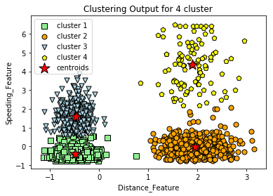

```python
plt.scatter(driver_data_scaled[predicted_cluster_4==0,0], driver_data_scaled[predicted_cluster_4==0, 1], s=50, c='lightgreen',\
           marker='s', edgecolors='black', label='cluster 1')
plt.scatter(driver_data_scaled[predicted_cluster_4==1,0], driver_data_scaled[predicted_cluster_4==1, 1], s=50, c='orange',\
           marker='o', edgecolors='black', label='cluster 2')
plt.scatter(driver_data_scaled[predicted_cluster_4==2,0], driver_data_scaled[predicted_cluster_4==2, 1], s=50, c='lightblue',\
           marker='v', edgecolors='black', label='cluster 3')
plt.scatter(driver_data_scaled[predicted_cluster_4==3,0], driver_data_scaled[predicted_cluster_4==3, 1], s=50, c='yellow',\
           marker='p', edgecolors='black', label='cluster 4')
plt.scatter(km_scaled_1.cluster_centers_[:,0], km_scaled_1.cluster_centers_[:,1], s=250, c='red',\
           marker='*', edgecolors='black', label='centroids')
plt.legend(scatterpoints=1)
plt.xlabel("Distance_Feature")
plt.ylabel("Speeding_Feature")
plt.title("Clustering Output for 4 cluster")
plt.show()
```